# Exploratory Data Analysis on Air Quality Data

# Exploratory Data Analysis on Air Quality Data

## Introduction

In this analysis, we will explore the air quality data from various cities in India. The goal is to understand the distribution of air quality metrics, their relationship with weather variables, and build predictive models for the air quality metrics.

### Loading Libraries

```r
library(ggplot2)
library(googledrive)
library(dplyr, warn.conflicts = FALSE)
library(readr)
library(magrittr)
library(tidyr, warn.conflicts = FALSE)
library(corrplot)
library(caret)
library(lubridate, warn.conflicts = FALSE)
library(gridExtra, warn.conflicts = FALSE)
```

## Downloading Data

First, let’s download the input files from Google Drive to the local file system.

```r
DOWNLOAD_FILES <- FALSE
INPUT_DIR <- "../input"
INPUT_DIR_DRIVE_ID <- "1V7RvgCu65LSaa2JjeengEMKwIYAhpSt8"

if (DOWNLOAD_FILES) {
    if (!dir.exists(INPUT_DIR)) {
        cat("Creating input directory\n")
        dir.create(INPUT_DIR, showWarnings = FALSE)
    }

    # authenticate with Google Drive
    drive_auth()

    input_dirs <- drive_ls(as_id(INPUT_DIR_DRIVE_ID))

    # loop dirs and download files inside them
    for (i1 in seq_along(input_dirs$name)) {
        input_files <- drive_ls(as_id(input_dirs$id[i1]))

        input_subdir <- file.path(INPUT_DIR, input_dirs$name[i1])
        if (!dir.exists(input_subdir)) {
            cat("Creating input directory\n")
            dir.create(input_subdir, showWarnings = FALSE)
        }

        for (i2 in seq_along(input_files$name)) {
            source_path <- file.path(input_dirs$name[i1], input_files$name[i2])
            destination_path <- file.path(INPUT_DIR, input_dirs$name[i1], input_files$name[i2])
            cat(paste("Downloading", source_path, "to", destination_path, "\n"))

            drive_download(
                as_id(input_files$id[i2]),
                path = destination_path,
                overwrite = TRUE
            )
        }
    }
}
```

## Loading Data

```r
city_name_map <- data.frame(
    air_quality = c("Bengaluru", "Delhi", "Hyderabad", "Jaipur", "Mumbai"),
    weather = c("bengaluru", "delhi", "hyderabad", "jaipur", "bombay")
)

# load the air quality data
data_air_quality <- read_csv(
    file.path(INPUT_DIR, "air_quality", "city_hour.csv"),
    show_col_types = FALSE
)

# filter the data for the cities of interest
data_air_quality <- data_air_quality %>%
    filter(City %in% city_name_map$air_quality) %>%
    filter(Datetime < as.POSIXct("2020-01-01"))

summary(data_air_quality)
```

```
     City              Datetime                          PM2.5
 Length:197533      Min.   :2015-01-01 01:00:00.00   Min.   :   0.01
 Class :character   1st Qu.:2016-05-30 08:00:00.00   1st Qu.:  25.52
 Mode  :character   Median :2017-09-29 20:00:00.00   Median :  45.09
                    Mean   :2017-08-21 23:07:12.24   Mean   :  65.49
                    3rd Qu.:2018-11-15 09:00:00.00   3rd Qu.:  74.48
                    Max.   :2019-12-31 21:00:00.00   Max.   : 999.99
                                                     NA's   :39247
      PM10               NO              NO2              NOx
 Min.   :   0.01   Min.   :  0.01   Min.   :  0.01   Min.   :  0.00
 1st Qu.:  67.58   1st Qu.:  4.24   1st Qu.: 18.57   1st Qu.: 14.02
 Median : 106.80   Median :  9.05   Median : 29.30   Median : 26.20
 Mean   : 140.06   Mean   : 20.09   Mean   : 35.41   Mean   : 38.29
 3rd Qu.: 170.13   3rd Qu.: 19.70   3rd Qu.: 45.54   3rd Qu.: 44.89
 Max.   :1000.00   Max.   :497.40   Max.   :380.02   Max.   :491.89
 NA's   :54497     NA's   :33700    NA's   :33821    NA's   :18489
      NH3               CO              SO2               O3
 Min.   :  0.01   Min.   : 0.000   Min.   :  0.01   Min.   :  0.01
 1st Qu.: 14.38   1st Qu.: 0.270   1st Qu.:  4.64   1st Qu.: 18.22
 Median : 22.81   Median : 0.690   Median :  7.96   Median : 31.96
 Mean   : 27.53   Mean   : 1.125   Mean   : 10.77   Mean   : 40.07
 3rd Qu.: 35.09   3rd Qu.: 1.150   3rd Qu.: 13.20   3rd Qu.: 54.96
 Max.   :485.82   Max.   :49.960   Max.   :199.93   Max.   :497.62
 NA's   :57864    NA's   :7819     NA's   :36112    NA's   :39618
    Benzene           Toluene           Xylene            AQI
 Min.   :  0.000   Min.   :  0.00   Min.   :  0.00   Min.   : 10.0
 1st Qu.:  0.160   1st Qu.:  0.62   1st Qu.:  0.00   1st Qu.: 80.0
 Median :  0.860   Median :  2.87   Median :  0.15   Median :116.0
 Mean   :  2.008   Mean   :  8.17   Mean   :  1.26   Mean   :153.6
 3rd Qu.:  2.290   3rd Qu.:  9.18   3rd Qu.:  1.02   3rd Qu.:195.0
 Max.   :372.790   Max.   :499.40   Max.   :189.11   Max.   :877.0
 NA's   :21030     NA's   :32336    NA's   :109392   NA's   :37492
  AQI_Bucket
 Length:197533
 Class :character
 Mode  :character
```

```r
# % of NA by column
cat("NA values by column:\n")
```

```
NA values by column:
```

```r
sapply(data_air_quality, function(x) sum(is.na(x)) / length(x))
```

```
      City   Datetime      PM2.5       PM10         NO        NO2        NOx
0.00000000 0.00000000 0.19868579 0.27588808 0.17060441 0.17121696 0.09359955
       NH3         CO        SO2         O3    Benzene    Toluene     Xylene
0.29293333 0.03958326 0.18281502 0.20056396 0.10646322 0.16369923 0.55379101
       AQI AQI_Bucket
0.18980120 0.18980120
```

Observations:

- There are 12 numeric columns we could use as response variables: PM2.5, PM10, NO, NO2, NOx, NH3, CO, SO2, O3, Benzene, Toluene, Xylene.
- AQI is calculated based on the above columns, so we will not use AQI itself as a response variable.
- All these numeric columns have up to 55% missing values.

## Exploratory Data Analysis

### Distribution of Response Variables

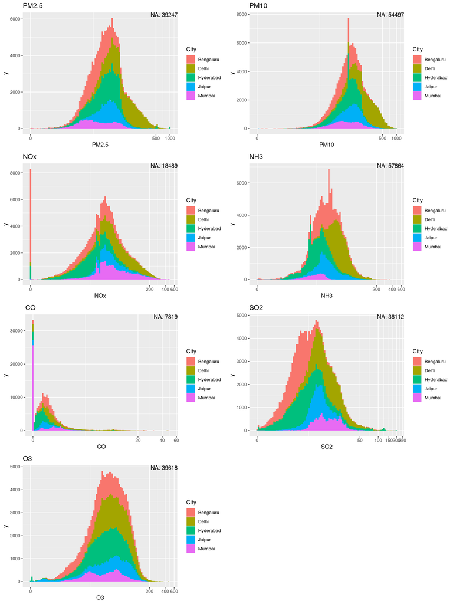

```r
# plot the distribution of the response variables
response_vars <- c("PM2.5", "PM10", "NOx", "NH3", "CO", "SO2", "O3")

plot_list <- list()

for (var in response_vars) {
    non_na_data <- data_air_quality %>% filter(!is.na(.data[[var]]))
    n_na <- sum(is.na(data_air_quality[[var]]))

    # color different cities differently
    # and scale the x-axis using a pseudo-log transformation
    p <- ggplot(non_na_data, aes_string(x = var, fill = "City")) +
        geom_histogram(bins = 100) +
        scale_x_continuous(trans=scales::pseudo_log_trans(base = 10)) +
        labs(title = var) +
        # annotate in the upper right corner
        annotate("text", x = Inf, y = Inf, hjust = 1, vjust = 1, label = paste("NA:", n_na))

    plot_list <- c(plot_list, list(p))
}
grid.arrange(grobs = plot_list, ncol = 2)
```

Observations:

- The distributions of the response variables are right-skewed with a long tail.

### Yearly Trend Analysis

Let’s plot the monthly boxplots of the response variables for each city.

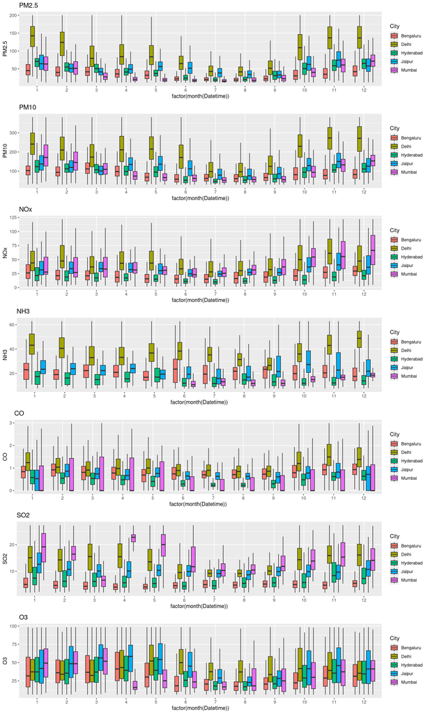

```r
plot_list <- list()

# plot boxplots for the response variables by City and Month
for (var in response_vars) {
    p <- ggplot(
            data_air_quality,
            aes_string(x = "factor(month(Datetime))", y = var, fill = "City")
        ) +
        geom_boxplot(outlier.shape = NA) +
        scale_y_continuous(limits = quantile(data_air_quality[[var]], c(0.05, 0.95), na.rm=TRUE)) +
        labs(title = var)

    plot_list <- c(plot_list, list(p))
}

grid.arrange(grobs = plot_list, ncol = 1)
```

Observations:

- The response variables show some seasonal patterns.
- Patterns are similar across cities, but the scale of the values is different.

### Loading Weather Data

```r
# load the weather data from multiple CSV files
data_weather <- list()

for (city in city_name_map$weather) {
    file_path <- file.path(INPUT_DIR, "weather", paste0(city, ".csv"))
    this_data <- read_csv(file_path, show_col_types = FALSE)
    this_data$City <- city_name_map$air_quality[city_name_map$weather == city]
    data_weather[[length(data_weather) + 1]] <- this_data

    # cat(paste("Loaded weather data for city", city, "\n"))
}
data_weather <- bind_rows(data_weather)

# filter the data
data_weather <- data_weather %>%
    filter(date_time >= as.POSIXct("2015-01-01")) %>%
    filter(date_time < as.POSIXct("2020-01-01"))

summary(data_weather)
```

```
   date_time                      maxtempC        mintempC      totalSnow_cm
 Min.   :2014-12-31 22:00:00   Min.   :15.00   Min.   : 3.00   Min.   :0
 1st Qu.:2016-04-01 09:45:00   1st Qu.:28.00   1st Qu.:19.00   1st Qu.:0
 Median :2017-07-01 21:30:00   Median :31.00   Median :23.00   Median :0
 Mean   :2017-07-01 21:30:00   Mean   :31.64   Mean   :22.75   Mean   :0
 3rd Qu.:2018-10-01 09:15:00   3rd Qu.:35.00   3rd Qu.:27.00   3rd Qu.:0
 Max.   :2019-12-31 21:00:00   Max.   :52.00   Max.   :43.00   Max.   :0
    sunHour       uvIndex...6      uvIndex...7     moon_illumination
 Min.   : 3.80   Min.   : 3.000   Min.   : 1.000   Min.   :  0.00
 1st Qu.: 8.70   1st Qu.: 6.000   1st Qu.: 1.000   1st Qu.: 18.00
 Median :11.60   Median : 7.000   Median : 5.000   Median : 46.00
 Mean   :10.84   Mean   : 6.691   Mean   : 4.357   Mean   : 46.11
 3rd Qu.:11.60   3rd Qu.: 7.000   3rd Qu.: 7.000   3rd Qu.: 73.00
 Max.   :14.00   Max.   :11.000   Max.   :11.000   Max.   :100.00
   moonrise           moonset            sunrise            sunset
 Length:219120      Length:219120      Length:219120     Length:219120
 Class :character   Class :character   Class1:hms        Class1:hms
 Mode  :character   Mode  :character   Class2:difftime   Class2:difftime
                                       Mode  :numeric    Mode  :numeric


   DewPointC        FeelsLikeC      HeatIndexC      WindChillC
 Min.   :-22.00   Min.   : 5.00   Min.   : 5.00   Min.   : 5.00
 1st Qu.:  9.00   1st Qu.:25.00   1st Qu.:25.00   1st Qu.:24.00
 Median : 17.00   Median :29.00   Median :29.00   Median :28.00
 Mean   : 14.81   Mean   :29.42   Mean   :29.53   Mean   :27.97
 3rd Qu.: 21.00   3rd Qu.:34.00   3rd Qu.:34.00   3rd Qu.:32.00
 Max.   : 30.00   Max.   :61.00   Max.   :61.00   Max.   :52.00
  WindGustKmph     cloudcover        humidity         precipMM
 Min.   : 0.00   Min.   :  0.00   Min.   :  2.00   Min.   : 0.00000
 1st Qu.:10.00   1st Qu.:  2.00   1st Qu.: 32.00   1st Qu.: 0.00000
 Median :15.00   Median : 11.00   Median : 51.00   Median : 0.00000
 Mean   :16.49   Mean   : 23.51   Mean   : 50.91   Mean   : 0.08593
 3rd Qu.:21.00   3rd Qu.: 40.00   3rd Qu.: 70.00   3rd Qu.: 0.00000
 Max.   :85.00   Max.   :100.00   Max.   :100.00   Max.   :17.90000
    pressure        tempC        visibility     winddirDegree   windspeedKmph
 Min.   : 987   Min.   : 0.0   Min.   : 0.000   Min.   :  0.0   Min.   : 0.00
 1st Qu.:1006   1st Qu.:23.0   1st Qu.:10.000   1st Qu.:105.0   1st Qu.: 8.00
 Median :1010   Median :27.0   Median :10.000   Median :222.0   Median :11.00
 Mean   :1009   Mean   :26.9   Mean   : 9.857   Mean   :195.1   Mean   :11.93
 3rd Qu.:1013   3rd Qu.:31.0   3rd Qu.:10.000   3rd Qu.:278.0   3rd Qu.:15.00
 Max.   :1026   Max.   :51.0   Max.   :20.000   Max.   :360.0   Max.   :47.00
     City
 Length:219120
 Class :character
 Mode  :character
```

Observations:

- There are no missing values in the weather data.

### Distribution of Weather Variables

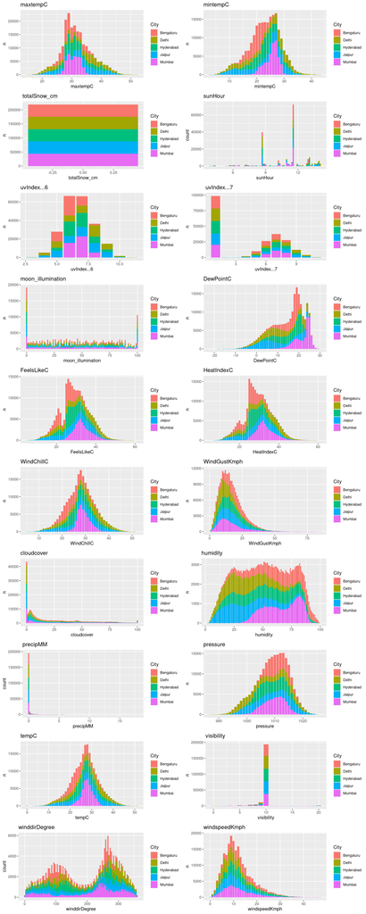

```r
# plot the distribution of the weather variables
weather_vars <- c(
    "maxtempC", "mintempC", "totalSnow_cm", "sunHour", "uvIndex...6", "uvIndex...7", "moon_illumination",
    "DewPointC", "FeelsLikeC", "HeatIndexC", "WindChillC", "WindGustKmph", "cloudcover", "humidity",
    "precipMM", "pressure", "tempC", "visibility", "winddirDegree", "windspeedKmph"
)

plot_list <- list()
for (var in weather_vars) {
    col_is_int <- all(as.integer(data_weather[[var]]) == data_weather[[var]])
    n_unique <- length(unique(data_weather[[var]]))

    if (col_is_int && n_unique <= 101) {
        # count the number of observations for each value per City
        barplot_data <- data_weather %>%
            group_by(City, !!sym(var)) %>%
            summarise(n = n(), .groups = "drop") %>%
            ungroup()

        # color different cities differently
        p <- ggplot(barplot_data, aes_string(x = var, y = "n", fill = "City")) +
            geom_bar(stat = "identity") +
            labs(title = var)
    } else {
        # color different cities differently
        p <- ggplot(data_weather, aes_string(x = var, fill = "City")) +
            geom_histogram(bins = min(n_unique, 101)) +
            labs(title = var)
    }

    plot_list <- c(plot_list, list(p))
}

grid.arrange(grobs = plot_list, ncol = 2)
```

## Feature Engineering

The response variables are right-skewed, we will use the log(y + 1) transformation to make the data more normally distributed.

```r
# merge the air quality and weather data
data_merged <- inner_join(
    data_air_quality,
    data_weather,
    by = c("City", "Datetime" = "date_time")
)

# create a new variable for the hour of the day
data_merged$hour_of_day <- as.numeric(format(data_merged$Datetime, "%H"))
data_merged$hour_cos <- cos(2 * pi * data_merged$hour_of_day / 24)
data_merged$hour_sin <- sin(2 * pi * data_merged$hour_of_day / 24)
data_merged$hour_of_day <- factor(data_merged$hour_of_day)

# create a new variable for the day of the week
data_merged$day_of_week <- as.numeric(format(data_merged$Datetime, "%u"))
data_merged$day_of_week <- factor(data_merged$day_of_week)

# create a new variable for the month of the year
data_merged$month_of_year <- as.numeric(format(data_merged$Datetime, "%m"))
data_merged$month_of_year <- factor(data_merged$month_of_year)

# convert wind direction to a sin-cos pair
data_merged$winddir_cos <- cos(2 * pi * data_merged$winddirDegree / 360)
data_merged$winddir_sin <- sin(2 * pi * data_merged$winddirDegree / 360)

# convert the City variable to a factor
data_merged$City <- factor(data_merged$City)

# log(y + 1) transformation for the response variables
data_merged[response_vars] <- log(data_merged[response_vars] + 1)
```

Let’s scale the numeric features to have zero mean and unit variance.

```r
# determine the numeric features automatically
numeric_vars <- sapply(data_merged, is.numeric)

# remove the response variables from the numeric features
numeric_vars <- numeric_vars & !names(data_merged) %in% (data_air_quality %>% select(-City, -Datetime) %>% colnames())

# scale the numeric variables
data_merged[numeric_vars] <- scale(data_merged[numeric_vars])
```

## Correlation Analysis

### Feature-Feature Correlation

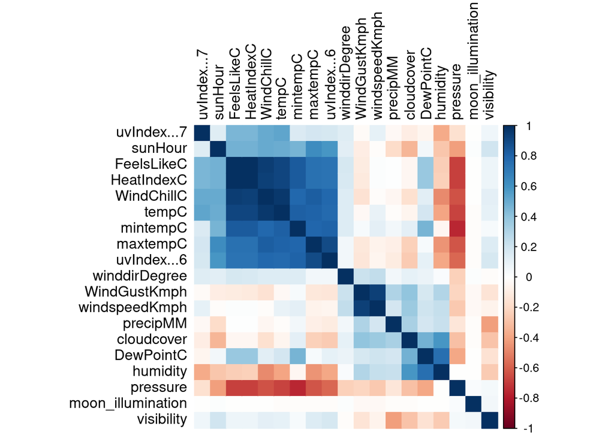

```r
# calculate the correlation matrix
correlation_matrix <- cor(
    data_merged[, weather_vars],
    use = "pairwise.complete.obs"
)

# remove rows and columns with all NA values
correlation_matrix <- correlation_matrix[
    !apply(is.na(correlation_matrix), 1, all),
    !apply(is.na(correlation_matrix), 2, all)
]

# plot the correlation matrix
corrplot(
    correlation_matrix,
    method = "color",
    tl.col = "black",
    order = "hclust"
)
```

### Feature-Response Correlation

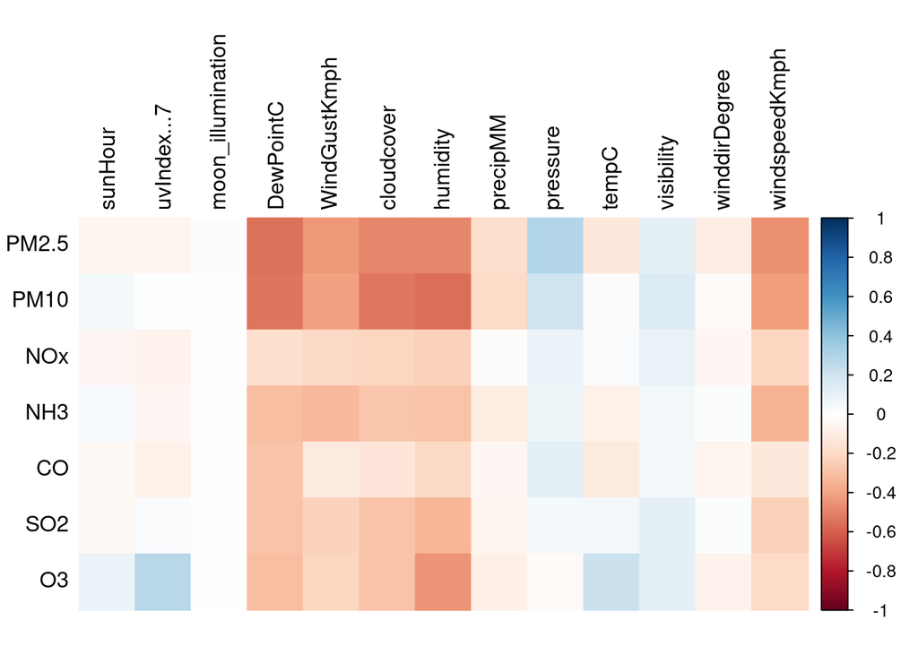

```r
feature_vars <- c(
    "sunHour", "uvIndex...7", "moon_illumination",
    "DewPointC", "WindGustKmph", "cloudcover", "humidity",
    "precipMM", "pressure", "tempC", "visibility", "winddirDegree", "windspeedKmph"
)

# calculate the correlation matrix
correlation_matrix <- cor(
    data_merged[, response_vars],
    data_merged[, feature_vars],
    use = "pairwise.complete.obs"
)

# plot the correlation matrix
corrplot(
    correlation_matrix,
    method = "color",
    tl.col = "black"
)
```

Observations:

## Building a Model

Since the data is from multiple cities, we will build separate models for each city.

```r
feature_vars <- c(
    "sunHour", "uvIndex...7", "moon_illumination", "DewPointC", "WindGustKmph", "cloudcover",
    "humidity", "precipMM", "pressure", "tempC", "visibility", "windspeedKmph", "day_of_week",
    "month_of_year", "hour_cos", "hour_sin", "winddir_cos", "winddir_sin"
)

feature_importance <- list()

for (city in city_name_map$air_quality) {
    cat(paste("\nFitting models for", city, "\n"))

    data_city <- data_merged %>%
        filter(City == city)

    for (var in response_vars) {
        # cat(paste("Fitting model for", var))

        model <- lm(data_city[[var]] ~ ., data = data_city[, feature_vars])
        # model <- lm(log(data_city[[var]] + 1) ~ ., data = data_city[, feature_vars])

        # add the model to the list of feature importance
        feature_importance_row <- data.frame(
            feature = rownames(summary(model)$coefficients)[-1],
            estimate = summary(model)$coefficients[-1, 1],
            response_var = var,
            city = city
        )
        rownames(feature_importance_row) <- NULL
        feature_importance <- c(feature_importance, list(feature_importance_row))

        # evaluate the model
        cat(paste(city, var, ":", round(summary(model)$r.squared, 3), "\n"))
    }
}
```

```
Fitting models for Bengaluru
Bengaluru PM2.5 : 0.314
Bengaluru PM10 : 0.342
Bengaluru NOx : 0.176
Bengaluru NH3 : 0.079
Bengaluru CO : 0.047
Bengaluru SO2 : 0.075
Bengaluru O3 : 0.348

Fitting models for Delhi
Delhi PM2.5 : 0.635
Delhi PM10 : 0.51
Delhi NOx : 0.176
Delhi NH3 : 0.32
Delhi CO : 0.17
Delhi SO2 : 0.265
Delhi O3 : 0.18

Fitting models for Hyderabad
Hyderabad PM2.5 : 0.496
Hyderabad PM10 : 0.578
Hyderabad NOx : 0.205
Hyderabad NH3 : 0.243
Hyderabad CO : 0.116
Hyderabad SO2 : 0.305
Hyderabad O3 : 0.352

Fitting models for Jaipur
Jaipur PM2.5 : 0.382
Jaipur PM10 : 0.354
Jaipur NOx : 0.252
Jaipur NH3 : 0.247
Jaipur CO : 0.143
Jaipur SO2 : 0.074
Jaipur O3 : 0.286

Fitting models for Mumbai
Mumbai PM2.5 : 0.663
Mumbai PM10 : 0.588
Mumbai NOx : 0.259
Mumbai NH3 : 0.49
Mumbai CO : 0.128
Mumbai SO2 : 0.421
Mumbai O3 : 0.412
```

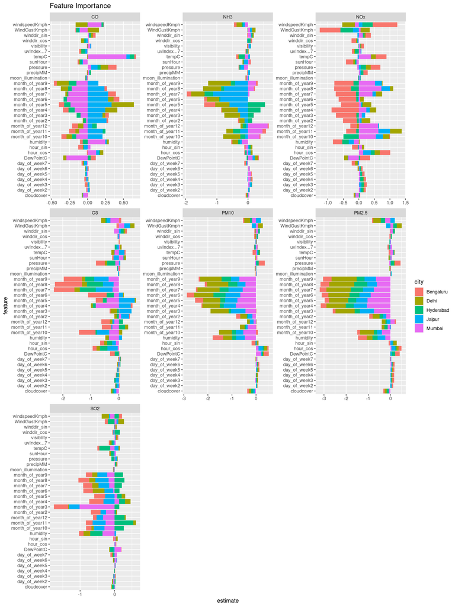

```r
feature_importance <- bind_rows(feature_importance)

# plot the feature importance
ggplot(feature_importance, aes(x = estimate, y = feature, fill = city)) +
    geom_bar(stat = "identity") +
    facet_wrap(~response_var, scales = "free") +
    labs(title = "Feature Importance")
```

```r
# vif_rows <- list()
# for (var in response_vars) {
#     cat(paste("Checking for multicollinearity for", var, "\n"))

#     # calculate the VIF for each predictor variable
#     model <- lm(data_merged[[var]] ~ ., data = data_merged[, c(var, feature_vars)])
#     vif_values <- car::vif(model)

#     vif_row <- as.data.frame(t(vif_values[-1, 3]))
#     vif_row[["response_var"]] <- var

#     vif_rows <- c(vif_rows, list(vif_row))
# }

# vif_data <- bind_rows(vif_rows)
# print(vif_data)
```